# Projet 0: OPSDB

Ce premier projet avait pour but de créer une base de donnée reprenant le contenu RP du forum à l'aide de de bots. Je vais présenter dans ce notebook quelques résultats intéressants issus des données récoltées. Les données utilisées tout au long de cette démonstration représentent l'état du forum au 26 janvier 2019.

Commençons par se connecter à la base de donnée.

```python
%load_ext sql
```

```python
%sql sqlite:///db/ops.db
```

```
'Connected: @db/ops.db'
```

## Aperçu

### Répartition des factions

Dans un premier temps, faisons quelques observations générales sur les membres et les rps du forum.

```python
%matplotlib inline
import pandas as pnd
import matplotlib.pyplot as plt
import numpy as np
import nltk
nltk.download('punkt')
from models import db_connect
from sqlalchemy.orm import sessionmaker
from nltk.tokenize import word_tokenize
conn = db_connect().connect()
```

```python
df = pnd.read_csv('data/faction_repartition.csv', header=0)
df['Color'] = df['Color'].str.pad(width=7, side='left', fillchar='#')
```

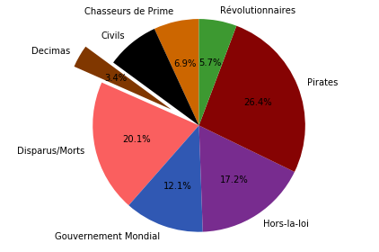

```python
# Create a pie chart
plt.pie(df['characters'],labels=df['Faction'], shadow=False,
    colors=df['Color'], explode=(0, 0, 0.3, 0, 0, 0, 0, 0),
    startangle=90, autopct='%1.1f%%',
    )
# View the plot drop above
plt.axis('equal')

# View the plot
plt.tight_layout()
plt.show()
```

Sans grande surprise, les pirates et les hors-la-loi semblent être parmis les plus nombreux. Mettons cette information sous forme de fromage pour pouvoir mieux observer la répartition proportionnelle de chaque faction parmi les personnages-joueurs.

Intéressons-nous ensuite à quelques mesures générales concernant le RP sur OPS. Commençons par le nombre de rps et de posts.

```python
rps = pnd.read_sql('SELECT * FROM rps', conn)
posts = pnd.read_sql('SELECT * FROM posts', conn)
rps = rps.set_index('r_id')
rps.count()
```

```
title          1888
chrono         1888
status         1888
url            1888
location_id    1888
dtype: int64
```

```python
print(posts.count())
ext_dates = posts.agg({'date':['min','max']})
import dateparser
min_d = dateparser.parse(ext_dates['date']['min'])
max_d = dateparser.parse(ext_dates['date']['max'])
delta =  max_d - min_d
print('days since the first post: {}'.format(delta.days))
```

```
p_id     23679
text     23679
url      23679
date     23679
rp_id    23679
dtype: int64
days since the first post: 3009
```

On constate qu'à la date du 26/01/2019, OPS (dans sa version actuelle) est actif depuis **3009 jours**, ce qui équivaut environ à **8,24 années**. Sur ce laps de temps, les membres ont créés **1888 rps** dans lesquels ils ont publiés **23 679 posts**. Ces nombres ont été calculés en ne tenant compte que des rps actuellement non archivés.

Si on fait rapidement le calcul, ceci nous donne **7,9** posts par jours en moyenne, soit environ **236 posts** en moyenne par mois.

### Nombre de posts dans le temps

Pour mieux se rendre compte des implications de ces nombres colossaux, observons la répartitions des posts dans le temps. Pour des raisons de lisibilités, calculons le nombre de posts écrits par quadrimestre, pour chaque année.

```python
posts = posts.sort_values('date')
posts = posts.set_index('date')
posts.index = pnd.to_datetime(posts.index)
posts['P'] = posts['rp_id'].apply(lambda x: 1 if rps.chrono[x] == 'P' else 0)
posts['FB'] = posts['rp_id'].apply(lambda x: 1 if rps.chrono[x] == 'FB' else 0)
posts['Total'] = posts.eval('P + FB')
posts['A'] = posts.index.year
posts['M'] = posts.index.month
posts['B'] = posts.index.date
#posts.head()
```

| date | p_id | text | url | rp_id | P | FB | Total |
| --- | --- | --- | --- | --- | --- | --- | --- |
| 2011-09-05 21:31:00 | 115 | La nouvelle année à Luvneel \nU\nne nouvelle ... | http://www.op-seken.com/t60-la-nouvelle-annee-... | 60 | 1 | 0 | 1 |
| 2011-09-08 22:50:00 | 197 | Journal de bord\n1er Septembre\nJe viens de pr... | http://www.op-seken.com/t98-un-voyage-incroyab... | 98 | 1 | 0 | 1 |
| 2011-09-19 14:41:00 | 435 | En cette belle matinée d’hiver, je fais le ple... | http://www.op-seken.com/t178-mission-gars-du-g... | 178 | 1 | 0 | 1 |
| 2011-09-22 13:51:00 | 492 | C\nela faisait déjà un bon moment que Mori mar... | http://www.op-seken.com/t194-mission-lecon-de-... | 194 | 1 | 0 | 1 |
| 2011-09-24 21:25:00 | 590 | Chimères...\nPourtant pas une illusion !\nTroi... | http://www.op-seken.com/t225-chimeres-pourtant... | 225 | 1 | 0 | 1 |

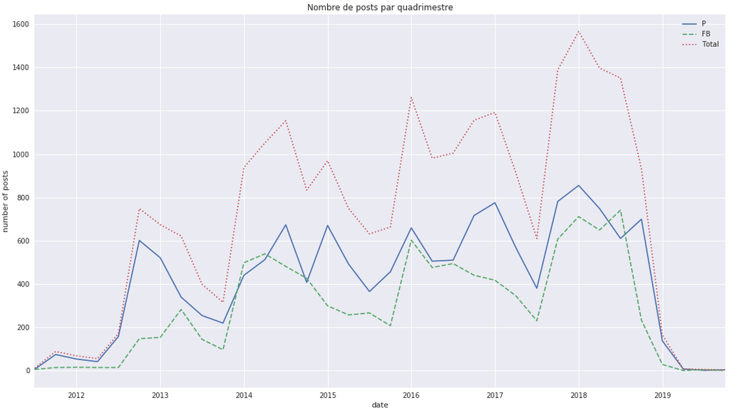

```python
data = pnd.DataFrame({'P':posts.P, 'FB':posts.FB, 'Total':posts.Total})
with plt.style.context('seaborn'):
    plot = data.resample('Q').sum().plot(figsize=(18, 10), style=['-', '--', ':'])
    plot.set_ylabel('number of posts')
    plot.set_title('Nombre de posts par quadrimestre')
    fig = plot.get_figure()
    fig.savefig("img/post_chrono.png")
    plot
```

On observe sur le graphique temporel que le nombre total de posts (la ligne rouge en pointillés) est en forme de "dents de scie" avec des hauts et des bas. Les pics se trouvent en général à cheval entre deux années tandis que les creux se trouvent en général en milieu d'année, à l'exception de l'année 2014 où on a un pic de posts en milieu d'année.

On peut facilement comprendre la nature de ces pics d'activité lorsqu'on prête attentions aux courbes pour les présents et flashbacks. Les régions à fortes activités sont en générales des régions où le nombre de posts au présent excède le nombre de posts en flashback, ce qui est caractéristique du comportement des membres durant les events.

A la lumière de cette constatation et en fouilant un peu dans les sujets crées de l'époque, on comprend que la forme de la courbe début-milieu 2014 correspond en fait au *premier event de Mars* qui, bien qu'ayant débuté en octobre 2013, s'est étalé jusqu'en avril 2014 et a par la suite débouché sur plusieures animations.

## Passé, présent, voyage dans le temps

- il y a davantage de présents que de FB en général
- cette différence est accrue juste avant, pendant et juste après l'event
- Elle est faible voire inexistante en temps normal

```python
rps['FB'] = rps['chrono'].apply(lambda x: 1 if x == 'FB' else 0)
rps['P'] = rps['chrono'].apply(lambda x: 1 if x == 'P' else 0)
rps['chrono_total'] = rps.eval('FB + P')
data_c = pnd.DataFrame({'P':rps.P, 'FB':rps.FB, 'Total':rps.chrono_total})
```

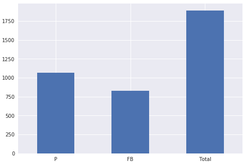

```python
with plt.style.context('seaborn'):
    plot = data_c.sum().plot.bar(rot=0)
    fig = plot.get_figure()
    fig.savefig('img/hist_global_FB_P.png')
```

Sans surprises, il y a actuellement plus de rp au présent que de flashbacks. Voyons maintenant comment ces derniers se répartissent parmis les personnages-joueurs actuels.

```python
chrono_ratio = pnd.read_csv('data/per_member_fb_p_ratio.csv', header=0)
```

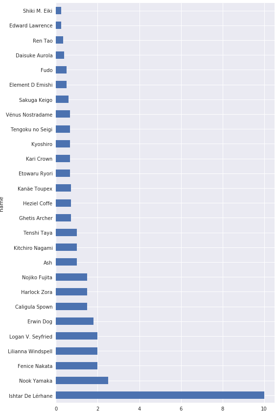

```python
data_cn = chrono_ratio.set_index('name')
with plt.style.context('seaborn'):
    plot = data_cn['ratio'].plot(figsize=(8, 15), kind='barh')
    fig = plot.get_figure()
    fig.savefig('img/hist_FB_P.png')
```

J'ai baptisé ce graphique : "**Hall of Fame des spammeurs**". Il est intéressant parce qu'il montre le ratio FB - présent pour chaque personnage, classés de bas vers le haut(donc plus le perso est en bas, plus il a participé à un nombre élevé de FB par rapport à son nombre de présents). A noter que ceux dont le pseudo n'apparait sont les personnages qui n'ont jamais réalisé de FB ou de présent (c'est le cas de 'Ayn par exemple, qui n'a que des posts au présent à son actif et n'est donc pas compté).

Ce petit classement tient par ailleurs uniquement compte de l'activité des personnages durant l'année qui vient de s'écouler, sans quoi il y aurait un biais envers les personnages plus anciens, ce qui rend le cas d'Ishtar d'autant plus incroyable quand on sait que le personnage a participé a **39** rp en 2018.

## Better, Faster, Longer ?

Le premier aperçu nous a fourni une idée générale de la quantité de posts sur OPS ainsi que de leur répartition par personnage joueur, selon les temporalités de rp. Maintenant que nous avons cette vision d'ensemble, allons explorer plus en détail un autre aspect du contenu rp d'OPS : **la longueur**. Sujet de nombreux débats en son temps, la longueur est une composante majeure du système RP d'OPS. Nous allons donc la décliner à différente sauces et voir quelles conclusions peuvent en être tiré.

Plusieurs éléments peuvent entrer en ligne de compte lorsqu'on parle de longueur d'un rp. On peut se concentrer sur le nombre de pages, de pages word, de posts, de mots, de caractères, etc. De la manière dont on choisit d'interpréter la longueur découlera donc forcément des manières de noter différentes. Avant la 2e maj d'uniformisation des notations de mi-2014, ces critères étaient laissés à la libre interprétation du noteur (oui, c'était un peu le far-west).

### Le nombre de post

Si on analayse la longueur en ne tenant uniquement compte du nombre de post, on peut intuitivement penser que ce nombre sera plus élevé pour les multis que pour les solos. Voyons voir si cette intuition se vérifie empiriquement.

```python
solo_multi = pnd.read_csv('data/per_rp_multi_solo_ratio.csv', header=0)
```

```python
solo_multi = solo_multi.sort_values('rid')
solo_multi = solo_multi.set_index('rid')
#solo_multi.head()
```

| rid | title | chrono | nParticipants | nPosts | rpType |
| --- | --- | --- | --- | --- | --- |
| 98 | Un voyage, incroyable dans un lieu macabre [Clos] | P | 1 | 1 | SOLO |
| 240 | [flashback] Campagne contre les brigands des m... | FB | 1 | 1 | SOLO |
| 268 | [Mission] C'est pas facile tous les jours | P | 1 | 1 | SOLO |
| 319 | Une journée banale pour un Marine sur Shabondy | P | 1 | 1 | SOLO |
| 357 | Partition mythique [Clos] | P | 1 | 1 | SOLO |

```python
solo_multi['rClass'] = solo_multi.eval('chrono + rpType')
c = {
    'FBMULTI': '#DE0784',
    'PMULTI': '#DD0A0E',
    'FBSOLO': '#07C1E1',
    'PSOLO': '#0A0DCD'
}
numbers = {
    1:'one',
    2:'two'
}
solo_multi['cParticipants'] = solo_multi['nParticipants'].apply(lambda x: 3 if x > 2 else x)
solo_multi['colour'] = solo_multi['rClass'].apply(lambda x: c[x])
```

```
count    228.000000
mean       1.706140
std        1.963669
min        1.000000
25%        1.000000
50%        1.000000
75%        1.000000
max       13.000000
Name: SOLO, dtype: float64
count    442.000000
mean      17.841629
std       14.287533
min        1.000000
25%        8.000000
50%       14.000000
75%       22.000000
max      107.000000
Name: MULTI, dtype: float64
```

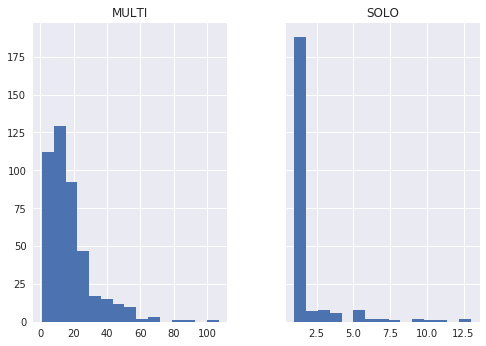

```python
multi = solo_multi.loc[solo_multi['rpType'] == 'MULTI', 'nPosts']
solo = solo_multi.loc[solo_multi['rpType'] == 'SOLO', 'nPosts']
data = pnd.DataFrame({
    'MULTI': multi,
    'SOLO': solo
})
with plt.style.context('seaborn'):
    data.hist( bins=15, sharey=True)
#print(data['SOLO'].describe())
#print(data['MULTI'].describe())
```

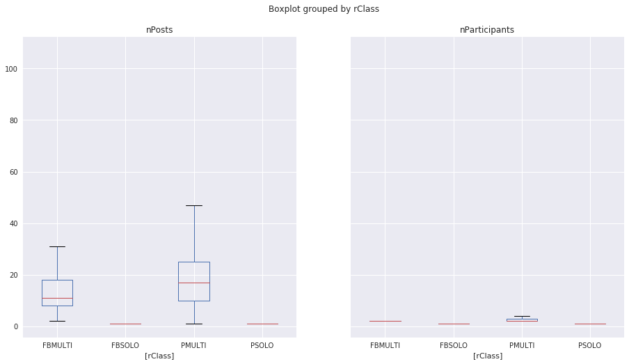

```python
with plt.style.context('seaborn'):
    plot = solo_multi.boxplot(column=['nPosts', 'nParticipants'], by=['rClass'], layout=(1,2), figsize=(15,8))
```

```python
dtype={'solos':np.int32, 'multis':np.int32, 'ratios':np.float64}
data_ms = pnd.read_csv('data/per_member_multi_solo_ratio.csv', header=0, sep='\t', dtype=dtype)
data_ms = data_ms.set_index('cname')
```

```python
data_ms_g = pnd.read_csv('data/per_member_multi_solo_whole.csv', header=0, sep='\t', dtype=dtype)
data_ms_g = data_ms_g.set_index('cname')
ms_g = data_ms_g.loc[data_ms_g.index.isin(data_ms.index.values)]
ms = data_ms.loc[data_ms.index.isin(ms_g.index.values)]
ind = np.arange(len(ms_g['ratio'].values))
```

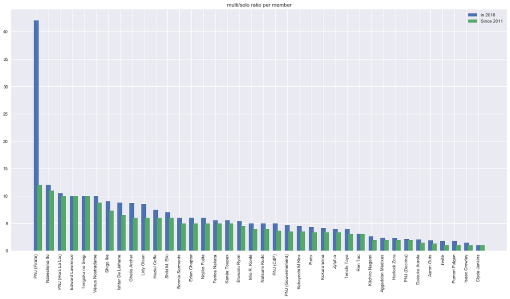

```python
with plt.style.context('seaborn'):
    plt.figure(figsize=(20,10))
    ax = plt.subplot(111)
    p1 = ax.bar(ind, ms_g['ratio'], width=0.4, align='center')
    p2 = ax.bar(ind+0.3, ms['ratio'], width=0.4, align='center')

    plt.title('multi/solo ratio per member')
    plt.xticks(ind, ms_g.index.values, rotation='vertical')
    #plt.yticks(np.arange(0, 81, 10))
    plt.legend((p1[0],p2[0] ), ('in 2018', 'Since 2011'))
    plt.show()
```

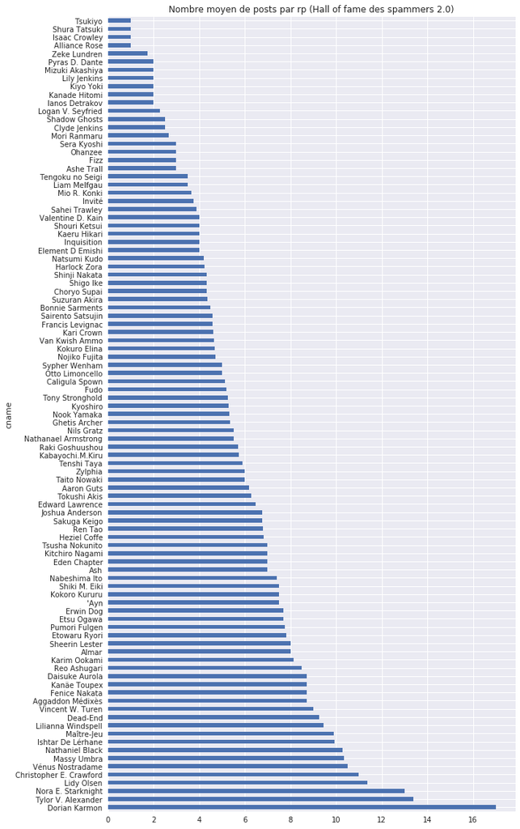

```python
data_ppr = pnd.read_csv('data/post_per_rp.csv', header=0,sep='\t', dtype={'post_per_rp': np.float64})
data_ppr = data_ppr.set_index('cname')
with plt.style.context('seaborn'):
    plot = data_ppr['post_per_rp'].plot(figsize=(10, 20), kind='barh')
    plt.title('Nombre moyen de posts par rp (Hall of fame des spammers 2.0)')
    fig = plot.get_figure()
    fig.savefig('img/hist_PPR.png')
```

## La longueur du texte

L'avantage avec le nombre de posts est qu'il est très simple à calculer, que ce soit pour un humain ou pour une machine. On peut donc facilement classer les personnages-joueurs selon leur moyenne de posts par rp, au cours de l'année dernière. En revanche, en se contentant uniquement du nombre de post comme indicateur de longueur, on perd de vue la véritable longueur des textes rédigés par les membres. Ce critère a désormais une place prépondérante dans la mesure de la longueur.

Vouloir utiliser la longueur du texte est une bonne chose, mais comment mesurer exactement cette dernière ? Par le nombre de lignes ? Par le nombre de phrases, de mots, ou de lettres ? A nouveau, OPS est passé par plusieurs phases et actuellement, dans le cas des présentations par exemple, seul le nombre de mots est pris en compte. Nous allons donc faire de même pour l'analyse qui suit, en essayant de voir si ceux qui écrivent les posts les plus longs sont également ceux qui postent le plus de posts par rp.

```python
# add word counts of each post
posts_wc = pnd.read_csv('data/posts_wc.zip', header=0, parse_dates=['date'])
posts_wc = posts_wc.set_index('date')
posts = posts.join(posts_wc)
```

```python
posts['SOLO'] = posts['rp_id'].apply(lambda x: 1 if len(posts.loc[posts['rp_id'] == x]) > 1 else 0)
```

| date | p_id | text | url | rp_id | P | FB | Total | A | M | B | wc | SOLO |
| --- | --- | --- | --- | --- | --- | --- | --- | --- | --- | --- | --- | --- |
| 2011-09-05 21:31:00 | 115 | La nouvelle année à Luvneel \nU\nne nouvelle ... | http://www.op-seken.com/t60-la-nouvelle-annee-... | 60 | 1 | 0 | 1 | 2011 | 9 | 2011-09-05 | 3079 | 0 |
| 2011-09-08 22:50:00 | 197 | Journal de bord\n1er Septembre\nJe viens de pr... | http://www.op-seken.com/t98-un-voyage-incroyab... | 98 | 1 | 0 | 1 | 2011 | 9 | 2011-09-08 | 1232 | 0 |
| 2011-09-19 14:41:00 | 435 | En cette belle matinée d’hiver, je fais le ple... | http://www.op-seken.com/t178-mission-gars-du-g... | 178 | 1 | 0 | 1 | 2011 | 9 | 2011-09-19 | 1849 | 0 |
| 2011-09-22 13:51:00 | 492 | C\nela faisait déjà un bon moment que Mori mar... | http://www.op-seken.com/t194-mission-lecon-de-... | 194 | 1 | 0 | 1 | 2011 | 9 | 2011-09-22 | 1772 | 0 |
| 2011-09-24 21:25:00 | 590 | Chimères...\nPourtant pas une illusion !\nTroi... | http://www.op-seken.com/t225-chimeres-pourtant... | 225 | 1 | 0 | 1 | 2011 | 9 | 2011-09-24 | 2346 | 0 |

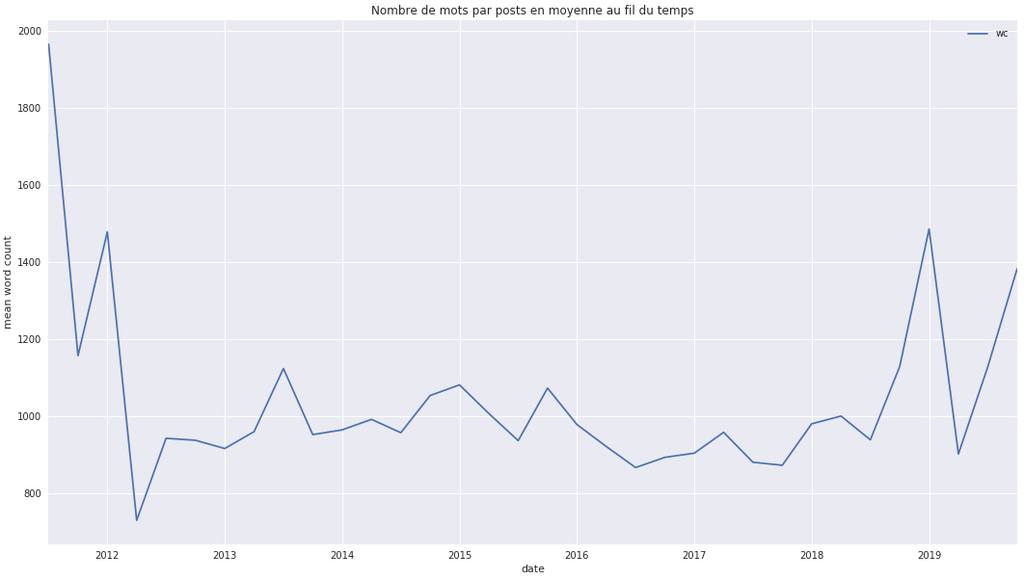

```python
with plt.style.context('seaborn'):
    plot = posts.resample('Q')['wc'].mean().plot(figsize=(18, 10), style=['-', '--', ':'])
    h, l = plot.get_legend_handles_labels()
    plot.legend(h, l)
    plot.set_ylabel('mean word count')
    plot.set_title('Nombre de mots par posts en moyenne au fil du temps')
    fig = plot.get_figure()
    fig.savefig("img/post_wc_time.png")
    plot
```

Ce graphe nous montre quelque chose d'intéressant : dans les premiers moments de la version actuelle d'OPS, les membres **écrivaient tous des pavés**. 1500 mots en moyenne par posts est un nombre qui reste largement supérieur à ce qui se fera par la suite (oublions l'hiver 2018 pour l'instant). C'est un ressenti que tous les anciens pourront confirmer, le style d'OPS était fortement tourné vers la quantité. C'est d'autant plus intéressant quand on se souvient du barème de l'époque et surtout de la manière dont la quantité était comptabilisée (comme je l'ai déjà dit souvent, c'était le far-west). Cette tendance à écrire de très longs posts était déjà présente sur la V1.

Du coup grosse chute au premier quadrimestre de 2012, signe d'une période de crise. [La Wayback Machine](https://web.archive.org/web/20130114221636/http://www.op-seken.com/) de la page d'accueil du forum ne remonte malheureusement que jusqu'en 2013, mais ceux qui étaient sur le forum à l'époque doivent se rappeler de cette période où le forum a faillit dispraitre pour vous situer le contexte: en février 2012, Raphael quitte le forum, qui subit en même temps une vague de ghostage (staff inclus). La situation devient critique et en juillet 2012, un certain modo particulièrement actif nommé Nakata passe admin.

Le graphe illustre bien ce qu'il s'est passé à la sortie de cet âge sombre concernant la longueur : on écrit moins long, beaucoup moins long. A partir de cette époque, OPS tourne autour des 1000 mots par posts et si vous reprenez le précédent graphe sur le nombre de posts étalés dans le temps, le timing coïncide parfaitement avec le moment où le nombre de posts produit a commencé à exploser. **OPS se met donc à écrire moins long, mais beaucoup plus souvent**.

Fast forward jusqu'en hiver 2018. Lancement de l'event tant attendu, qui vient couronner une année qui a battu nombreux records en terme d'activité. Qu'est-ce qu'on remarque ? **La taille moyenne des posts a considérablement augmenté durant l'event**. C'était le cas pour les events précédent, mais pas avec une telle intensité. Il serait intéressant d'investiguer ce point davantage pour essayer d'en identifier les causes sous-jacentes, mais je ne le ferai pas ici par souci de concision. A voir si c'est passagé ou si c'est une tendance qui va persister.